# Tyler, the Creator Sentiment Analysis

[figure not shown]

```
    - Jake Kovinsky
```

A look at the evolution of a versatile and unfilitered artist through data exploration using basic natural-language processing (NLP) algorithms.

**Key words**: data cleaning, data exploration, data visualization, Spotipy, GeniusLyrics, API, lexical richness, topic modeling, sentiment analysis, NLPs, sklearn

```python
import pandas as pd
import numpy as np
import re
from matplotlib import pyplot as plt
```

# Data Extraction

### Leveraging Spotify API + Genius Lyrics

Spotify actually keeps *a lot* of data on songs internally, which we can access through the Spotify API. The data I am most interested in for this project is Spotify's numerical data. This includes:

- popularity
- danceability
- loudness
- speechness
- acousticness
- instrumentalness
- valence
- tempo
- duration_ms

To get our lyrics, we will acess the LyricsGenius API. In order to make such requests for both API versions, we will need a `client_id` and a `client_secret` that you'll use to identify your machine to respective servers.

#### Step 0: Install Libraries

Below are the necessary library packages to conenct to the Spotify and LyricsGenius APIs. If you do not have these dependencies already isntalled, try: "conda install *package_name*" or "pip install *package_name*" if you are using Jupyter Notebook.

```python
import spotipy
from spotipy.oauth2 import SpotifyClientCredentials
import requests
from lyricsgenius import Genius
import lyricsgenius
```

#### Step 1: Connecting to the Spotify and Genius APIs

All information regarding the Spotify API (Spotipy) can be found [here](https://spotipy.readthedocs.io/en/2.16.1/) and all information regarding the Genius API (LyricsGenius) can be found [here](https://lyricsgenius.readthedocs.io/en/master/).

##### Connecting to Spotify API

First, we need to register as a Spotify developer. Directions to become a developer for free can be found [here](https://developer.spotify.com/). After registering, you will need to create an app through your dashboard, which will give you a unique client ID and client secret ID. These unique tokens will allow for streamless connection to Spotipy. Below is the code necessary to capture connection with Spotipy. For privacy purposes, I will not disclose my developer tokens.

```python
client_id = 'client_id'
client_secret = 'client_secret'
```

```python
client_credentials_manager = SpotifyClientCredentials(client_id=client_id, client_secret=client_secret)
sp = spotipy.Spotify(client_credentials_manager = client_credentials_manager)
```

##### Connecting LyricsGenius API

A very similar process will be carried out in order to connect to the LyricsGenius API. You can register with Genius by following the link [here](https://docs.genius.com/). Below is the code necessarry to capture a similar connection to the LyricsGenius API.

```python
client_access_token = 'client_access_token'
```

```python
LyricsGenius = lyricsgenius.Genius(client_access_token)
```

Both these types of authentication (class method) will create a Genius and Spotify object, respecitvely. Now using the `LyricsGenius` and `sp` objects, we can interact with both APIs to get the information we want!

#### Step 2: Scraping Data from Both APIs

##### Extracting Tracks From a Playlist

The method that I will use to extract features from Tyler's tracks will be performed by the "playlist_tracks" method. This method uses a system of uniform resource identifers (URIs), which point at each object (the songs contained in our playlist) within the API, and ouputs JSON data containing all the of information about this playlist. Fortunately, the Spotipy library does this for us! To perform this, I compiled all of Tyler's albums into a single playlist. Spotify then generates a `playlist_link`. The method below will now extract the URI for each song in the playlist link that I provide it.

```python
playlist_link = "https://open.spotify.com/playlist/1pWfaOrtN2rVKJNEk1WfQ0?si=f043404188e34f65"
playlist_URI = playlist_link.split("/")[-1].split("?")[0]
track_uris = [x["track"]["uri"] for x in sp.playlist_tracks(playlist_URI)["items"]]
```

Now that we have a list of track URIs, we can scrape the features from these tracks and then their lyrics from the LyricsGenius API. We can access the audio features with a single method of the Spotify object `audio_features(uri)`. We can extract song lyrics in tandem with both the Spotify and Genius objects with the following method below:

```python
song = LyricsGenius.search_song(artist_name, track["track"]["name"])
lyrics = song.lyrics
```

Note, that `track["track"]["name"]` is a method under the Spotify object. My method for collecting each songs' audio features is demonstrated below.

```python
# dictionary with features/lyrics as keys with empty values
d = {'song':[], 'album':[], 'lyrics':[], 'popularity':[],
             'danceability':[], 'energy':[],
              'key':[], 'loudness':[], 'mode':[],
              'speechiness':[],'acousticness':[],
              'instrumentalness':[], 'liveness':[],
              'valence':[], 'tempo':[], 'duration_ms':[]
             }
# audio features I will pass into Spotify object
f = ('danceability', 'energy', 'key', 'loudness', 'mode',
                 'speechiness', 'acousticness','instrumentalness', 'liveness',
                 'valence', 'tempo', 'duration_ms')
features = list(dict([(key, d[key]) for key in f]).keys())
```

```python
# extract data for each song in playist
for idx, track in enumerate(sp.playlist_tracks(playlist_URI)["items"]):
    c=0
    d['song'].append(track["track"]["name"])
    d['album'].append(track["track"]["album"]["name"])
    d['popularity'].append(track["track"]["popularity"])
    try:
        song = LyricsGenius.search_song('Tyler, The Creator', track["track"]["name"])
        d['lyrics'].append(song.lyrics)
        c+=1
    except:
        d['lyrics'].append(np.nan)
        print(f"some exception at {song}: {c}")
    for feature in features:
        d[feature].append(sp.audio_features(track_uris)[idx][feature])
```

```python
# convert dictionary to dataframe and export as csv for later
df = pd.DataFrame.from_dict(d)
df.to_csv(r'/Users/jakekovinsky/Desktop/Projects/Music/tyler_sentinment_5.csv', index=False)
```

Fantastic, now we have a dataframe of all the data we want for each of Tyler's songs!

# Import Data Frame

```python
df = pd.read_csv('tyler_sentinment_5.csv')
```

```python
df.head()
```

|  | song | album | lyrics | popularity | danceability | energy | key | loudness | mode | speechiness | acousticness | instrumentalness | liveness | valence | tempo | duration_ms |
| --- | --- | --- | --- | --- | --- | --- | --- | --- | --- | --- | --- | --- | --- | --- | --- | --- |
| 0 | Goblin | Goblin | Goblin Lyrics[Intro: Tyler, The Creator as Dr.... | 51 | 0.456 | 0.529 | 5 | -12.651 | 0 | 0.828 | 0.5340 | 0.000000 | 0.219 | 0.444 | 78.235 | 408520 |
| 1 | Yonkers | Goblin | Yonkers Lyrics[Intro]\nUh, Wolf Haley, Golf Wa... | 64 | 0.712 | 0.759 | 11 | -5.397 | 1 | 0.334 | 0.0161 | 0.080800 | 0.217 | 0.738 | 79.102 | 249333 |
| 2 | Radicals | Goblin | Radicals Lyrics[Intro]\nRandom disclaimer!\nHe... | 50 | 0.562 | 0.680 | 1 | -8.015 | 1 | 0.498 | 0.1540 | 0.095500 | 0.269 | 0.224 | 74.060 | 438333 |
| 3 | She | Goblin | She Lyrics[Verse 1: Frank Ocean]\nGolden rubbe... | 73 | 0.350 | 0.621 | 8 | -6.495 | 0 | 0.233 | 0.2560 | 0.000034 | 0.613 | 0.459 | 83.375 | 253387 |
| 4 | Transylvania | Goblin | Transylvania Lyrics[Intro]\nLeft Brain, Wolf H... | 45 | 0.572 | 0.638 | 7 | -11.868 | 1 | 0.424 | 0.0115 | 0.010400 | 0.201 | 0.197 | 122.448 | 192200 |

# Data Cleaning

There actually isn't a whole lot of cleaning we need to perform, but if you peak at some of the lyrics, there is unecessary text that is in between parentheses or brakcets that we can get rid of!

```python
def clean_lyrics(l):
    """
    Removes text inside brackets and other special characters that are
    unecessary to textual analysis

    Parameters
    ----------
    l : str
    Any piece of text
    """
    l = re.sub(r'[\(\[].*?[\)\]]', '', l)
    l = re.sub(r'([0-9]+)(Embed)', '', l)
    # there were a few inconsistencies in how lyrics were extracted
    if 'Lyrics' in l:
        # start string from first instance of a linebreak to remove song titles
        start = l.find("\n")
        l = l[start:]
    l = l.replace('\n', ' ')
    l = l.replace('\r', '')
    return l
```

```python
# there's one song that is purely instrumental
df = df.dropna()
```

```python
df['lyrics'] = df['lyrics'].map(clean_lyrics)
```

# Exploratory Analysis

This exploration won't go into the lryical portion of our analysis yet, but I just want to get a feel of the numerical features we extracted from Spotify to see if we can already see any potential differences between Tyler's 6 albums.

```python
# we can drop these features for now ('mode' and 'key' were accidentally added)
df_numerical = df.drop(['song', 'mode', 'lyrics', 'key'], axis = 1)
```

```python
df_numerical.head()
```

|  | album | popularity | danceability | energy | loudness | speechiness | acousticness | instrumentalness | liveness | valence | tempo | duration_ms |
| --- | --- | --- | --- | --- | --- | --- | --- | --- | --- | --- | --- | --- |
| 0 | Goblin | 51 | 0.456 | 0.529 | -12.651 | 0.828 | 0.5340 | 0.000000 | 0.219 | 0.444 | 78.235 | 408520 |
| 1 | Goblin | 64 | 0.712 | 0.759 | -5.397 | 0.334 | 0.0161 | 0.080800 | 0.217 | 0.738 | 79.102 | 249333 |
| 2 | Goblin | 50 | 0.562 | 0.680 | -8.015 | 0.498 | 0.1540 | 0.095500 | 0.269 | 0.224 | 74.060 | 438333 |
| 3 | Goblin | 73 | 0.350 | 0.621 | -6.495 | 0.233 | 0.2560 | 0.000034 | 0.613 | 0.459 | 83.375 | 253387 |
| 4 | Goblin | 45 | 0.572 | 0.638 | -11.868 | 0.424 | 0.0115 | 0.010400 | 0.201 | 0.197 | 122.448 | 192200 |

### Multiple Facet Histograms

Histograms for each respective statistic relative to every album will provide a nice visual of how these features are distributed overtime.

```python
albums = df_numerical['album'].to_numpy()
```

```python
def create_data(df, col):
    albums = df_numerical['album'].to_numpy()
    df = df[col].to_numpy()
    return (albums, df)
```

```python
def facet_hist(groups, data, m_rows, m_cols, col, figsize, **kwargs):
    """
    Creates faceted histograms such that there is a seperate axis and
    histogram for each group from a dataset

    Parameters
    ----------
    groups : ndarray
        1D array containing data with 'int' type between 0 and 1
    data : ndarray
        2D array containg data with 'float' type as a function of groups
        plus gausian noise (bell curve)
    m_rows : int
        the number of desired rows in your faceted histogram
    m_cols : int
        the number of desired columns in your faceted histogram
    figsize : the size of the figure

    """
    if m_rows*m_cols == len(set(groups)): # check that rows & cols are configurable with amount of groups
        fig, axarr = plt.subplots(nrows = m_rows, ncols = m_cols, figsize = figsize) # set up plot(s)
        ix = 0 # free variable for group titles
        vals = list(set(groups)) # list of unqiue values in data
        #ordering = [0, 4, 3, 2, 5, 1]
        #vals = [vals[i] for i in ordering]
        vals = list(dict.fromkeys(groups))
        for i in range(m_cols):
            for j in range(m_rows):
                mask = groups == vals[ix] # mask group corresponding to value
                axarr[j, i].hist(data[mask], bins = 8, **kwargs) # plot histogram with data corresponding to True indices returned by mask
                axarr[j, i].set_title('{}'.format(vals[ix])) # title based off free variable
                axarr[j, 0].set_ylabel('Frequency') # y-label
                axarr[m_rows - 1, i].set_xlabel(col) # x-label
                fig.suptitle(f'Feature: {col}')
                ix += 1 # increment free variable
        plt.tight_layout() # ensures plots aren't squish
    else:
        raise ValueError('Value of n_groups in create_data() not configurable with function') # error if n_rows and m_cols not configurable with amount of groups
```

```python
cols = df_numerical.columns[1:]
```

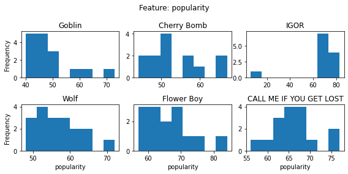

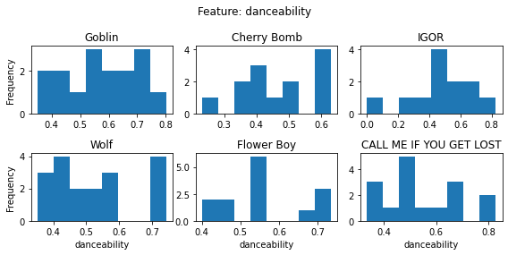

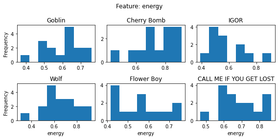

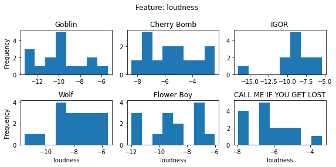

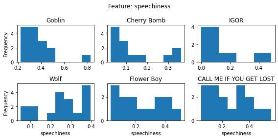

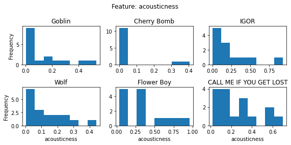

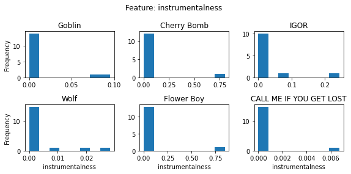

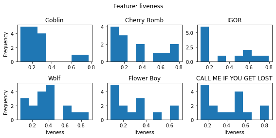

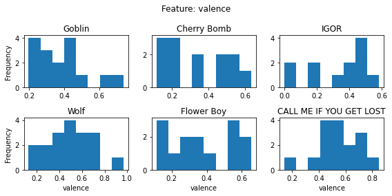

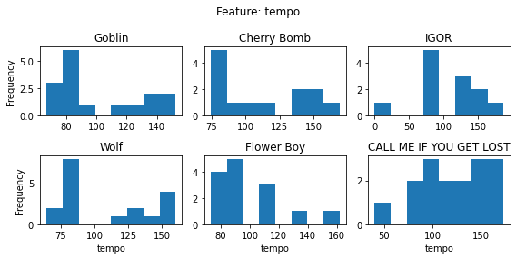

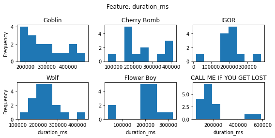

```python
for i in cols:
    groups, data = create_data(df_numerical, i)
    facet_hist(groups, data, 2, 3, i, figsize = (8, 4))
```

These distributions are nice, but let's get the averages for each statistic relative to every album so we can digest it a little better!

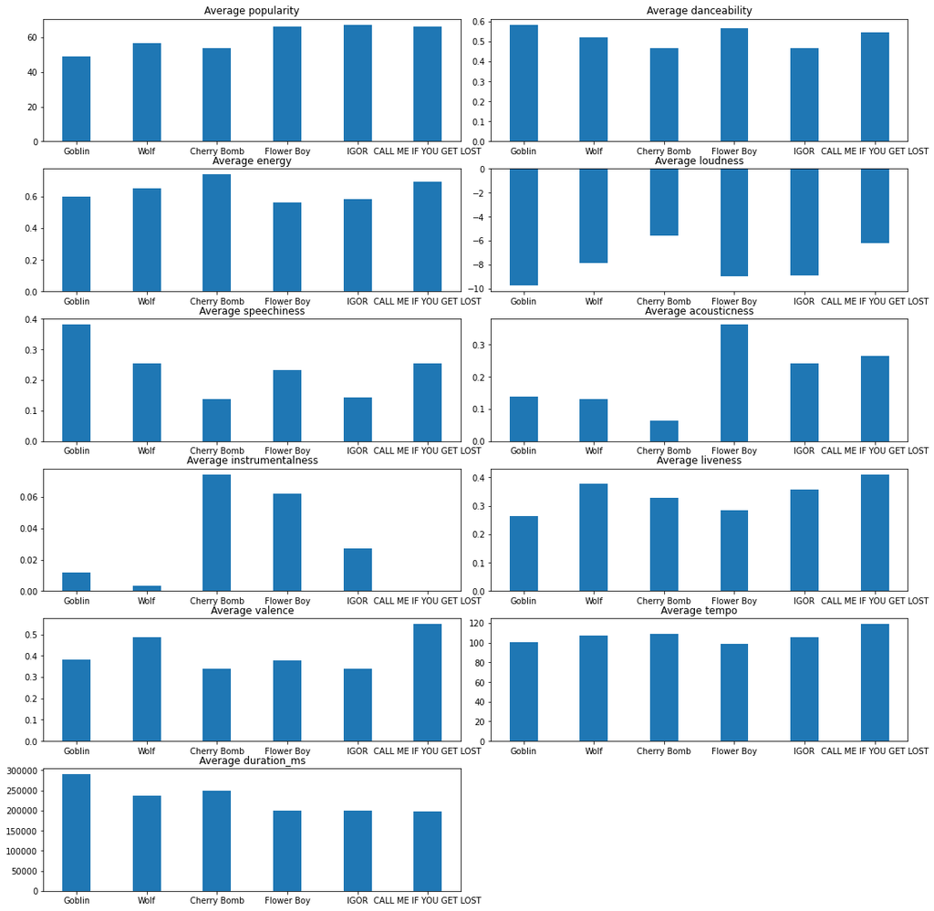

```python
fig, axarr = plt.subplots(6, 2, figsize = (15, 15))
plt.tight_layout(pad=0.4, w_pad=0.5, h_pad=1.2)
for idx, i in enumerate(cols):
    table=df_numerical.groupby(['album'])[i].mean().sort_values(ascending = False).reindex(["Goblin", "Wolf", "Cherry Bomb",
    "Flower Boy","IGOR", "CALL ME IF YOU GET LOST"]).reset_index()
    if idx % 2 == 0:
        axarr[int(idx/2), 0].bar(table['album'], table[i], width = 0.4)
        axarr[int(idx/2), 0].set_title(f"Average {i}")
    else:
        axarr[int(idx/2), 1].bar(table['album'], table[i], width = 0.4)
        axarr[int(idx/2), 1].set_title(f"Average {i}")
fig.delaxes(axarr[5, 1])
#plt.tight_layout()
```

Nice, we can see a few noticeable trends:

# Text Analysis

As mentioned above, Spotify does actually keep track of the presence of spoken words per track, but this only provides us with a value between 0 and 1.  
There's actually a pretty neat library called `LexicalRichness`, which we will dive deaper into later, that provides us with a method for counting the total amount of words in a piece of text!

```python
from lexicalrichness import LexicalRichness
```

```python
df.head()
```

|  | song | album | lyrics | popularity | danceability | energy | key | loudness | mode | speechiness | acousticness | instrumentalness | liveness | valence | tempo | duration_ms |
| --- | --- | --- | --- | --- | --- | --- | --- | --- | --- | --- | --- | --- | --- | --- | --- | --- |
| 0 | Goblin | Goblin | You wouldn't do that Tyler, kill yourself or ... | 51 | 0.456 | 0.529 | 5 | -12.651 | 0 | 0.828 | 0.5340 | 0.000000 | 0.219 | 0.444 | 78.235 | 408520 |
| 1 | Yonkers | Goblin | Uh, Wolf Haley, Golf Wang, go I'm a fuckin'... | 64 | 0.712 | 0.759 | 11 | -5.397 | 1 | 0.334 | 0.0161 | 0.080800 | 0.217 | 0.738 | 79.102 | 249333 |
| 2 | Radicals | Goblin | Random disclaimer! Hey, don't do anything tha... | 50 | 0.562 | 0.680 | 1 | -8.015 | 1 | 0.498 | 0.1540 | 0.095500 | 0.269 | 0.224 | 74.060 | 438333 |
| 3 | She | Goblin | Golden rubbers in these denim pockets On my ... | 73 | 0.350 | 0.621 | 8 | -6.495 | 0 | 0.233 | 0.2560 | 0.000034 | 0.613 | 0.459 | 83.375 | 253387 |
| 4 | Transylvania | Goblin | Left Brain, Wolf Haley Golf Wang, Free Earl, ... | 45 | 0.572 | 0.638 | 7 | -11.868 | 1 | 0.424 | 0.0115 | 0.010400 | 0.201 | 0.197 | 122.448 | 192200 |

```python
df['num_words'] = df['lyrics'].apply(lambda x : LexicalRichness(x).words)
```

```python
df.head()
```

|  | song | album | lyrics | popularity | danceability | energy | key | loudness | mode | speechiness | acousticness | instrumentalness | liveness | valence | tempo | duration_ms | num_words |
| --- | --- | --- | --- | --- | --- | --- | --- | --- | --- | --- | --- | --- | --- | --- | --- | --- | --- |
| 0 | Goblin | Goblin | You wouldn't do that Tyler, kill yourself or ... | 51 | 0.456 | 0.529 | 5 | -12.651 | 0 | 0.828 | 0.5340 | 0.000000 | 0.219 | 0.444 | 78.235 | 408520 | 1209 |
| 1 | Yonkers | Goblin | Uh, Wolf Haley, Golf Wang, go I'm a fuckin'... | 64 | 0.712 | 0.759 | 11 | -5.397 | 1 | 0.334 | 0.0161 | 0.080800 | 0.217 | 0.738 | 79.102 | 249333 | 550 |
| 2 | Radicals | Goblin | Random disclaimer! Hey, don't do anything tha... | 50 | 0.562 | 0.680 | 1 | -8.015 | 1 | 0.498 | 0.1540 | 0.095500 | 0.269 | 0.224 | 74.060 | 438333 | 834 |
| 3 | She | Goblin | Golden rubbers in these denim pockets On my ... | 73 | 0.350 | 0.621 | 8 | -6.495 | 0 | 0.233 | 0.2560 | 0.000034 | 0.613 | 0.459 | 83.375 | 253387 | 698 |
| 4 | Transylvania | Goblin | Left Brain, Wolf Haley Golf Wang, Free Earl, ... | 45 | 0.572 | 0.638 | 7 | -11.868 | 1 | 0.424 | 0.0115 | 0.010400 | 0.201 | 0.197 | 122.448 | 192200 | 590 |

Time for a nice bar plot visuallizing our results!

```python
avg_words = df.groupby(['album'])['num_words'].mean().reset_index()
```

```python
avg_words = avg_words.reindex([3, 5, 1, 2, 4, 0]).reset_index().drop(['index'], axis = 1)
```

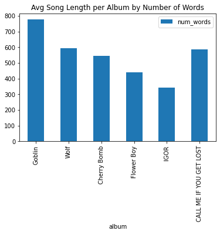

```python
avg_words.plot.bar(x='album', y='num_words', title='Avg Song Length per Album by Number of Words')
```

Like we saw from Spotify's audio speechiness feature, we see a downward trend in how many words are spoken on average per track for each album.

Fantastic, now I am interested in seeing how some of Spotify's audio features relate to this lyrical phenomenon. In order to get a nice visualization, I am going to standarize/normalize each feature that I am interested in! To do this, we can import the `preporcessing` package from our friends at `sklearn`!

```python
from sklearn import preprocessing
```

```python
# group data by album
avg_album = df.groupby(['album'])[['num_words', 'valence', 'popularity', 'acousticness', 'instrumentalness', 'energy']].mean().reset_index().reindex([3, 5, 1, 2, 4, 0]).reset_index().drop(['index'], axis = 1)
```

```python
avg_album
```

|  | album | num_words | valence | popularity | acousticness | instrumentalness | energy |
| --- | --- | --- | --- | --- | --- | --- | --- |
| 0 | Goblin | 777.062500 | 0.382063 | 49.125000 | 0.137824 | 0.011807 | 0.599063 |
| 1 | Wolf | 594.000000 | 0.488333 | 56.500000 | 0.130281 | 0.003335 | 0.655333 |
| 2 | Cherry Bomb | 545.230769 | 0.339000 | 53.769231 | 0.064006 | 0.074318 | 0.739846 |
| 3 | Flower Boy | 441.357143 | 0.380000 | 66.285714 | 0.362536 | 0.061929 | 0.564286 |
| 4 | IGOR | 343.166667 | 0.337983 | 67.166667 | 0.241179 | 0.027037 | 0.584500 |
| 5 | CALL ME IF YOU GET LOST | 587.625000 | 0.547500 | 66.187500 | 0.264587 | 0.000472 | 0.692688 |

```python
X_data = avg_album.drop(['album'], axis = 1)
```

```python
y_data = avg_album['album']
```

```python
standard = preprocessing.scale(X_data)
```

```python
avg_album = pd.DataFrame(standard)
```

```python
avg_album = avg_album.rename(columns={0:"num_words", 1:"valence", 2:"popularity", 3:"acousticness", 4:"instrumentalness", 5:"energy"})
```

```python
avg_album['album'] = y_data
```

```python
# standardized/normalized dataset
avg_album
```

|  | num_words | valence | popularity | acousticness | instrumentalness | energy | album |
| --- | --- | --- | --- | --- | --- | --- | --- |
| 0 | 1.695107 | -0.387798 | -1.519403 | -0.625024 | -0.629818 | -0.643182 | Goblin |
| 1 | 0.339973 | 0.967073 | -0.473521 | -0.700774 | -0.926070 | 0.256603 | Wolf |
| 2 | -0.021045 | -0.936811 | -0.860784 | -1.366263 | 1.556274 | 1.607985 | Cherry Bomb |
| 3 | -0.789977 | -0.414093 | 0.914235 | 1.631397 | 1.123016 | -1.199272 | Flower Boy |
| 4 | -1.516840 | -0.949773 | 1.039167 | 0.412805 | -0.097183 | -0.876040 | IGOR |
| 5 | 0.292782 | 1.721402 | 0.900307 | 0.647858 | -1.026219 | 0.853906 | CALL ME IF YOU GET LOST |

Now, let's plot!

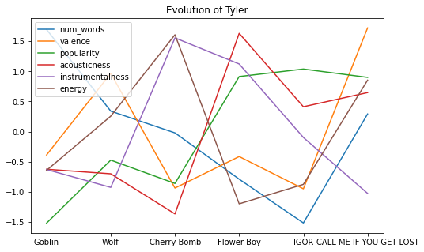

```python
fig = plt.figure(figsize = (8, 5))
for i in list(avg_album.columns)[:6]:
    plt.plot(avg_album["album"], avg_album[i], label = i)
plt.title('Evolution of Tyler')
plt.legend()
```

The graph is a little tough to read, but it's interesting to see how positively correlated acousticness and popularity is with Tyler's albums overtime. Additionally, it is interesting to observe that the number of words spoken is inverserly associated with that positive trend. However, I am interested to see whether or not this downward trend in spoken words has any sort of relationship with Tyler's lexical richness or diversity. Are his lyrics becoming shorter but more rich in vocabulary?

### LexicalRichness

Lexical richness is commonly defined by the quality of vocabulary used in a single corpus or piece of text by linguistics. By some, this is interpreted as the variety of lexis, or in another words, simply the diversity of words. There are many ways to describe this phenomenon analytically, but one of the most popular indexes used is called the type-token ratio (TTR), where the type of word is divided by how many instances of that word appear in said corpus. Fortunately, we don't need to write too much code to implement this formula since we can import the `LexicalRichness` package (which has already been done). This library has a method called Measure of Textual Lexical Diversity, denoted as `mtld`, which we will use to apply this idea.

To get a better feel for Tyler's sentiment, I am interested in learning about his usage of explicit words. To do this, I am going to import the `profanity` package, which checks whether a lexicon is explicit or not.

```python
from better_profanity import profanity
```

```python
def count_dirty(x):
    """
    Return the amount of explicit words in a given text

    Parameters
    ----------
    x : str, any textual piece

    Returns
    ------
    count : int, the amount of explicit words in a piece of text
    """
    words = LexicalRichness(x).wordlist
    count=0
    for word in words:
        if profanity.contains_profanity(word):
            count+=1
    return count
```

```python
df["dirty_words"] = df['lyrics'].apply(count_dirty)
```

```python
df.head()
```

|  | song | album | lyrics | popularity | danceability | energy | key | loudness | mode | speechiness | acousticness | instrumentalness | liveness | valence | tempo | duration_ms | num_words | dirty_words |
| --- | --- | --- | --- | --- | --- | --- | --- | --- | --- | --- | --- | --- | --- | --- | --- | --- | --- | --- |
| 0 | Goblin | Goblin | You wouldn't do that Tyler, kill yourself or ... | 51 | 0.456 | 0.529 | 5 | -12.651 | 0 | 0.828 | 0.5340 | 0.000000 | 0.219 | 0.444 | 78.235 | 408520 | 1209 | 57 |
| 1 | Yonkers | Goblin | Uh, Wolf Haley, Golf Wang, go I'm a fuckin'... | 64 | 0.712 | 0.759 | 11 | -5.397 | 1 | 0.334 | 0.0161 | 0.080800 | 0.217 | 0.738 | 79.102 | 249333 | 550 | 50 |
| 2 | Radicals | Goblin | Random disclaimer! Hey, don't do anything tha... | 50 | 0.562 | 0.680 | 1 | -8.015 | 1 | 0.498 | 0.1540 | 0.095500 | 0.269 | 0.224 | 74.060 | 438333 | 834 | 160 |
| 3 | She | Goblin | Golden rubbers in these denim pockets On my ... | 73 | 0.350 | 0.621 | 8 | -6.495 | 0 | 0.233 | 0.2560 | 0.000034 | 0.613 | 0.459 | 83.375 | 253387 | 698 | 18 |
| 4 | Transylvania | Goblin | Left Brain, Wolf Haley Golf Wang, Free Earl, ... | 45 | 0.572 | 0.638 | 7 | -11.868 | 1 | 0.424 | 0.0115 | 0.010400 | 0.201 | 0.197 | 122.448 | 192200 | 590 | 62 |

Cool, so now we have added the amount of explicit words for each song in our dataframe denoted as `dirty_words`! To make our analysis faster, I am going to group our textual data that we have so far, including Tyler's lyrics, by each of his albums.

```python
txt = {"album":[], "corpus":[]}
```

```python
albums = list(dict.fromkeys(df['album']))
```

```python
albums
```

```
['Goblin',
 'Wolf',
 'Cherry Bomb',
 'Flower Boy',
 'IGOR',
 'CALL ME IF YOU GET LOST']
```

```python
# grouping/truncating corpus of text by album
for album in albums:
    s=''
    lyrics = df[df['album'] == album]['lyrics'].to_numpy()
    txt['album'].append(album)
    for i in lyrics:
        s+=i
    txt['corpus'].append(s)
```

```python
corpus_df = pd.DataFrame.from_dict(txt)
```

```python
corpus_df_1 = corpus_df
```

```python
corpus_df['lex_rich'] = corpus_df['corpus'].apply(lambda x : LexicalRichness(x).mtld(threshold=0.72))
```

```python
corpus_df['tot_words'] = corpus_df['corpus'].apply(lambda x : LexicalRichness(x).words)
```

```python
corpus_df['avg_dirty'] = df.groupby(['album'])[['dirty_words']].mean().reset_index().reset_index().reindex([3, 5, 1, 2, 4, 0]).reset_index().drop(['index'], axis = 1)['dirty_words']
```

```python
corpus_df
```

|  | album | corpus | lex_rich | tot_words | avg_dirty |
| --- | --- | --- | --- | --- | --- |
| 0 | Goblin | You wouldn't do that Tyler, kill yourself or ... | 50.769947 | 12433 | 62.687500 |
| 1 | Wolf | You are a hoe, you are a hoe You Fuck you, f... | 55.831970 | 10690 | 36.000000 |
| 2 | Cherry Bomb | Um, excuse me mister but can you please turn d... | 44.530689 | 7087 | 25.230769 |
| 3 | Flower Boy | How many cars can I buy till I run out of driv... | 26.824262 | 6175 | 12.071429 |
| 4 | IGOR | What? What? What? What? What? What? What? Wha... | 20.500248 | 4118 | 6.833333 |
| 5 | CALL ME IF YOU GET LOST | The sun beamin' Y'all ready? Ayo It's T, baby... | 49.198662 | 9398 | 17.875000 |

Again, let's normalize our data so that we can visualize all of these variables on a single graph.

```python
X_data = corpus_df.drop(['album', 'corpus'], axis = 1)
y_data = corpus_df['album']
X_data, y_data
```

```
(    lex_rich  tot_words  avg_dirty
 0  50.769947      12433  62.687500
 1  55.831970      10690  36.000000
 2  44.530689       7087  25.230769
 3  26.824262       6175  12.071429
 4  20.500248       4118   6.833333
 5  49.198662       9398  17.875000,
 0                     Goblin
 1                       Wolf
 2                Cherry Bomb
 3                 Flower Boy
 4                       IGOR
 5    CALL ME IF YOU GET LOST
 Name: album, dtype: object)
```

```python
standard = preprocessing.scale(X_data)
corpus_df = pd.DataFrame(standard)
```

```python
corpus_df = corpus_df.rename(columns={0:"lex_rich", 1:"tot_words", 2:"avg_dirty"})
corpus_df['album'] = y_data
```

```python
corpus_df
```

|  | lex_rich | tot_words | avg_dirty | album |
| --- | --- | --- | --- | --- |
| 0 | 0.729638 | 1.463327 | 1.932908 | Goblin |
| 1 | 1.118669 | 0.843678 | 0.496194 | Wolf |
| 2 | 0.250135 | -0.437215 | -0.083564 | Cherry Bomb |
| 3 | -1.110652 | -0.761437 | -0.791993 | Flower Boy |
| 4 | -1.596670 | -1.492716 | -1.073985 | IGOR |
| 5 | 0.608881 | 0.384363 | -0.479560 | CALL ME IF YOU GET LOST |

#### Visualizing Some of our Data using a Scatterplot Matrix

I relealized that it would be cool to see how some of textual variables play out holistically from our initial dataframe and how they relate to Tyler's trend in popularity and emphasis on acousticness. The only thing I need to do is apply that same `LexicalRichness` method to every instance of Tyler's songs, which is demonstrated directly below.

```python
df['lex_rich']=df['lyrics'].apply(lambda x : LexicalRichness(x).mtld(threshold=0.72))
```

```python
avg_album = avg_album
```

```python
def scatterplot_matrix(cols, figsize):
    """
    produces a scatterplot matrix
    cols : str
        list of strings, each of which correspond to column names from the happiness dataset
    figsize : tuple
        desired figure size of each plot in scatterplot matrix

    """
    fig, axarr=plt.subplots(nrows = len(cols), ncols = len(cols), figsize = figsize) # set up plot
    for i in range(len(cols)): # nested for-loop so that each that there is a plot for each possible pairs of variables
        for j in range(len(cols)):
            if i == j: # condition so that diagonal is empty for each variable
                axarr[j, i].set_title('{}'.format(cols[j]), fontsize = 10)
                axarr[j, i].set_ylabel('{}'.format(cols[i]))
            else:
                axarr[j, i].scatter(df[cols[j]], df[cols[i]]) # produce scatter plot
                axarr[j, i].set_title('{}'.format(cols[j]), fontsize = 10) # title corresponding to each instance of pairing variable
                my_number = np.corrcoef(df[cols[j]], df[cols[i]].to_numpy())[0][1] # correlation coefficient
                axarr[j, i].set(xlabel = r"$\rho$ = " + str(np.round(my_number, 2))) # set correlation coefficient to x-axis label
                axarr[j, i].set_ylabel('{}'.format(cols[i])) # variable being compared to all other instance variables
                fig.suptitle('Associations of Target Variables')
    plt.tight_layout()
```

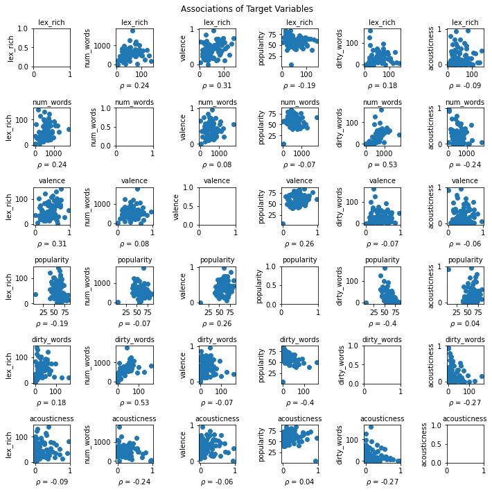

```python
scatterplot_matrix(["lex_rich", "num_words", "valence", "popularity", "dirty_words", "acousticness"], figsize = (10,10))
```

Some key takeaways:

- popularity and the amount of explicit words has an inverse relationship
- as the number of words per song drop, acousticness increases
- lexical richness and valence have a modest positive correlation
- the number of words used per song has a strong positive correlation with the usage of explicit words
- acousticness and usage of explicit words also has an inverse relationship

#### A Closer Look at Lexical Richness

In order to see how these trends play out over the course of each album, I will need to add the average song acousticness per album (which I did not do previously).

```python
corpus_df["acousticness"] = avg_album["acousticness"]
```

```python
corpus_df.columns.drop(['album'])
```

```
Index(['lex_rich', 'tot_words', 'avg_dirty', 'acousticness'], dtype='object')
```

Now it's time to plot!

[figure not shown]

```python
fig = plt.figure(figsize = (8, 5))
for i in list(corpus_df.columns.drop(['album']):
    plt.plot(corpus_df["album"], corpus_df[i], label = i)
plt.plot(corpus_df["album"], avg_album["popularity"], label = "popularity")
#plt.plot(corpus_df["album"], avg_album["valence"], label = "valence")
plt.title('Tyler\'s Lexical Richness by Album')
plt.legend()
```

```python
avg_album['tot_words'] = corpus_df['tot_words']
avg_album['avg_dirty'] = corpus_df['avg_dirty']
```

```python
# Pearson Correlation Coefficient
for i in avg_album.columns.drop('album'):
    pearson = np.corrcoef(corpus_df["lex_rich"], avg_album[i])[1][0]
    abs_pearson = abs(pearson)
    description = str()
    if abs_pearson >= 0 and abs_pearson < 0.20:
        decscription = '(very weak)'
    elif abs_pearson >= 0.20 and abs_pearson < 0.40:
        description = '(weak)'
    elif abs_pearson >= 0.40 and abs_pearson < 0.60:
        description = '(moderate)'
    elif abs_pearson >= 0.60 and abs_pearson < 0.80:
        description = '(strong)'
    else:
        description = '(very strong)'
    print(i, ": ", pearson, description)
```

[output not shown]

#### Wordcloud

Great, now let's make a word cloud of all Tyler's lyrics. To do this, we'll import the `WordCloud` package and truncate each of the album's text into a single string.

```python
from wordcloud import WordCloud
import nltk
#nltk.download()
from nltk.tokenize import word_tokenize
from nltk.corpus import stopwords
```

```python
corpus_df_1
```

|  | album | corpus | lex_rich | tot_words | avg_dirty |
| --- | --- | --- | --- | --- | --- |
| 0 | Goblin | You wouldn't do that Tyler, kill yourself or ... | 50.769947 | 12433 | 62.687500 |
| 1 | Wolf | You are a hoe, you are a hoe You Fuck you, f... | 55.831970 | 10690 | 36.000000 |
| 2 | Cherry Bomb | Um, excuse me mister but can you please turn d... | 44.530689 | 7087 | 25.230769 |
| 3 | Flower Boy | How many cars can I buy till I run out of driv... | 26.824262 | 6175 | 12.071429 |
| 4 | IGOR | What? What? What? What? What? What? What? Wha... | 20.500248 | 4118 | 6.833333 |
| 5 | CALL ME IF YOU GET LOST | The sun beamin' Y'all ready? Ayo It's T, baby... | 49.198662 | 9398 | 17.875000 |

```python
whole_txt = ''
for i in corpus_df_1['corpus']:
    whole_txt+=i
```

```python
# initialize words we do not want to display
stopwords = set(stopwords.words('english'))
stopwords.add('ha')
stopwords.add('na')
```

```python
cloud_whole = WordCloud(stopwords = stopwords).generate(whole_txt)
```

```python
# for explicit purposes, I will not display the word cloud
"""
fig = plt.figure(figsize = (20, 20))
plt.imshow(cloud_whole, interpolation='bilinear')
plt.axis('off')
plt.show()
"""
```

```
"\nfig = plt.figure(figsize = (20, 20))\nplt.imshow(cloud_whole, interpolation='bilinear')\nplt.axis('off')\nplt.show()\n"
```

A little explicit, but let's see if there are any impactful language trends throughout Tyler's lyrics overtime. We already saw a decrease trend in explicit word usage, so let's explore the world of topic modeling...

# Topic Modeling

The overall goal of topic modeling is to find "topics" in corpuses of text by grouping words together that provide an abstract overview. Our overall aim for this section is to get a topic-level summary of each of Tyler's albums overtime. Our methods will include substantiating a [term-document](https://en.wikipedia.org/wiki/Document-term_matrix) matrix in combination with awesome algorithms provided by `sklearn`.

Just think of the term-document matrix as a dataframe with a column for every possible word that exists in a piece of corpus. In each column, there exists a number that corresponds to how many times that lexicon appears in a subset of text.

Fortunately, our friends at `sklearn` provides us with a convenient solution!

```python
corpus_df_1
```

|  | album | corpus | lex_rich | tot_words | avg_dirty |
| --- | --- | --- | --- | --- | --- |
| 0 | Goblin | You wouldn't do that Tyler, kill yourself or ... | 50.769947 | 12433 | 62.687500 |
| 1 | Wolf | You are a hoe, you are a hoe You Fuck you, f... | 55.831970 | 10690 | 36.000000 |
| 2 | Cherry Bomb | Um, excuse me mister but can you please turn d... | 44.530689 | 7087 | 25.230769 |
| 3 | Flower Boy | How many cars can I buy till I run out of driv... | 26.824262 | 6175 | 12.071429 |
| 4 | IGOR | What? What? What? What? What? What? What? Wha... | 20.500248 | 4118 | 6.833333 |
| 5 | CALL ME IF YOU GET LOST | The sun beamin' Y'all ready? Ayo It's T, baby... | 49.198662 | 9398 | 17.875000 |

Note we could have used any of the dataframes I made previously that contain corpuses of text *per* album.

To begin, we are going to grab the `CountVectorizer` function from `sklearn.feature_extraction.text`. This module will give us a whole range of functionality when converting our textual data into quantitative numbers that we can feed our NLP machine learning algorithms.

```python
from sklearn.feature_extraction.text import CountVectorizer
vec=CountVectorizer(max_df=0.5, min_df=0, stop_words = stopwords)
```

Next, we can use the `CountVectorizer` object to fit our textual data into a nice dataframe using the built-in `fit_transform()` method. Below, I convert `counts` to a numpy array since `fit_transform()` returns a sparse matrix to save memory. After converting `counts` to a numpy array using the `toarray()` method, we construct a dataframe with labeled columns from our `CountVectorizer` object.

```python
counts = vec.fit_transform(corpus_df_1['corpus'])
counts=counts.toarray()
counts_df=pd.DataFrame(counts, columns = vec.get_feature_names())
df=pd.concat((corpus_df_1, counts_df), axis = 1)
```

```python
df.head()
```

|  | album | corpus | lex_rich | tot_words | avg_dirty | 000 | 06 | 09 | 100 | 12 | ... | ziploc | zipper | zombie | zone | zoning | zoo | zoom | zoomed | zucchinis | сould |
| --- | --- | --- | --- | --- | --- | --- | --- | --- | --- | --- | --- | --- | --- | --- | --- | --- | --- | --- | --- | --- | --- |
| 0 | Goblin | You wouldn't do that Tyler, kill yourself or ... | 50.769947 | 12433 | 62.687500 | 0 | 0 | 0 | 0 | 0 | ... | 0 | 0 | 1 | 1 | 0 | 0 | 2 | 0 | 0 | 2 |
| 1 | Wolf | You are a hoe, you are a hoe You Fuck you, f... | 55.831970 | 10690 | 36.000000 | 0 | 0 | 0 | 1 | 0 | ... | 2 | 1 | 0 | 0 | 3 | 0 | 0 | 0 | 0 | 0 |
| 2 | Cherry Bomb | Um, excuse me mister but can you please turn d... | 44.530689 | 7087 | 25.230769 | 2 | 0 | 1 | 0 | 0 | ... | 0 | 0 | 0 | 0 | 0 | 0 | 1 | 0 | 1 | 0 |
| 3 | Flower Boy | How many cars can I buy till I run out of driv... | 26.824262 | 6175 | 12.071429 | 0 | 2 | 0 | 1 | 1 | ... | 0 | 0 | 0 | 0 | 0 | 0 | 0 | 0 | 0 | 0 |
| 4 | IGOR | What? What? What? What? What? What? What? Wha... | 20.500248 | 4118 | 6.833333 | 0 | 0 | 0 | 0 | 0 | ... | 0 | 0 | 0 | 0 | 0 | 0 | 0 | 0 | 0 | 0 |

5 rows × 4721 columns

From an inital glance, some of the data we have included in our document-term matrix can be *dropped*. Hence we will,

```python
X=df.drop(['corpus', 'lex_rich', 'album', 'tot_words', 'avg_dirty'],axis=1)
```

```python
X
```

|  | 000 | 06 | 09 | 100 | 12 | 16 | 18 | 19 | 191 | 20 | ... | ziploc | zipper | zombie | zone | zoning | zoo | zoom | zoomed | zucchinis | сould |
| --- | --- | --- | --- | --- | --- | --- | --- | --- | --- | --- | --- | --- | --- | --- | --- | --- | --- | --- | --- | --- | --- |
| 0 | 0 | 0 | 0 | 0 | 0 | 0 | 0 | 1 | 0 | 1 | ... | 0 | 0 | 1 | 1 | 0 | 0 | 2 | 0 | 0 | 2 |
| 1 | 0 | 0 | 0 | 1 | 0 | 1 | 1 | 0 | 0 | 1 | ... | 2 | 1 | 0 | 0 | 3 | 0 | 0 | 0 | 0 | 0 |
| 2 | 2 | 0 | 1 | 0 | 0 | 0 | 0 | 0 | 1 | 0 | ... | 0 | 0 | 0 | 0 | 0 | 0 | 1 | 0 | 1 | 0 |
| 3 | 0 | 2 | 0 | 1 | 1 | 0 | 0 | 0 | 0 | 8 | ... | 0 | 0 | 0 | 0 | 0 | 0 | 0 | 0 | 0 | 0 |
| 4 | 0 | 0 | 0 | 0 | 0 | 0 | 0 | 0 | 0 | 0 | ... | 0 | 0 | 0 | 0 | 0 | 0 | 0 | 0 | 0 | 0 |
| 5 | 0 | 0 | 0 | 0 | 1 | 0 | 0 | 0 | 0 | 0 | ... | 0 | 0 | 0 | 1 | 0 | 1 | 0 | 1 | 0 | 0 |

6 rows × 4716 columns

Perfect, since topic modeling is considered *unsupervised learning* and thus we do not need a `Y` target variable, all we did was substantiate our predictor variables `X` produced by our term-document matrix. To do that, we ignored the columns `corpus`, `lex_rich`, `album`, `tot_words`, and `avg_dirty`.

Now for the most exciting part!

There are many types of topic modeling algorithms, but for our case we will use nonnegative matrix factorization (NMF). I won't go into the mathematical jargon of how NMF works, but in essence, NMF relies on linear algebra to decompose term-matrix documents into topics.

In essence, we start with some arbitrary matrix `X` defined by its documents (rows) and words (columns). Then we factor `X` into how many `documents x topics` we have multiplied by the number of `topics x words` exist in our matrix `X`. In other words, before the factorization we look at how often each word (a lexicon from each song lyric) appears in each document (or album). Subsequently, we then look at how strongly a topic is associated with each document.

Awesome, now we have a very surface-level understanding of how NMFs work (no problem!). Our NMF function insists that we specify `n_components`, which is the number of topics to find. Choosing the number of topics is sort of arbitrary, but let's choose 3 to see if there's any unique pattern of overlap between albums.

```python
from sklearn.decomposition import NMF
model = NMF(n_components=3, init = "random", random_state = 0)
model.fit(X)
```

```
NMF(init='random', n_components=3, random_state=0)
```

Now that we fit our model to our data, we have two import pieces to break down. We have the number of `components`, which we can think of as a collection of weights for each word defined by seperate rows. In our case, we rows 0, 1, 2. This is stored in our `components_` attribute of our model. Basically, these weights within each row correspond to how important a word is in each component or topic that our model has found.

```python
model.components_
```

```
array([[0.06822949, 0.        , 0.03411475, ..., 0.00470272, 0.03411475,
        1.33822937],
       [0.37614262, 1.17505803, 0.18807131, ..., 0.49608306, 0.18807131,
        0.        ],
       [0.07836328, 0.        , 0.03918164, ..., 0.00433445, 0.03918164,
        0.        ]])
```

```python
model.components_.shape
```

```
(3, 4716)
```

We can actually sort our weights by each row using the `argsort` method.

```python
orders=np.argsort(model.components_, axis = 1)
orders
```

```
array([[1430, 2098, 3961, ...,  499, 4037, 3257],
       [2357, 2527, 2529, ..., 3137, 2789,  504],
       [2357, 2420, 2417, ..., 3761, 4114,  588]])
```

Then let's utilize our numpy indexing abilities to arrange Tyler's words in ascending order by row.

```python
import_words=np.array(X.columns)[orders]
import_words
```

```
array([['ends', 'impala', 'stickers', ..., 'boppin', 'sunset', 'radical'],
       ['leopard', 'mass', 'massage', ..., 'pothole', 'november',
        'boredom'],
       ['leopard', 'loaf', 'llamas', ..., 'slater', 'tamale', 'bum']],
      dtype=object)
```

```python
def top_words(X, model, component, num_words):
    """
    returns the most important words by topic in descending order
    """
    orders = np.argsort(model.components_, axis = 1)
    import_words=np.array(X.columns)[orders]
    return import_words[component][-num_words:]
```

```python
albums = corpus_df_1['album'].to_numpy()
```

```python
albums
```

```
array(['Goblin', 'Wolf', 'Cherry Bomb', 'Flower Boy', 'IGOR',
       'CALL ME IF YOU GET LOST'], dtype=object)
```

Next, let's assign the relative importance of a topic per document (album). This can be accomplished by accessing the `transform()` attribute of our model.

```python
weights=model.transform(X)
weights
```

```
array([[1.4880777 , 0.        , 0.        ],
       [0.        , 0.        , 1.32517261],
       [0.08738702, 0.30211617, 0.07919709],
       [0.        , 0.93122155, 0.        ],
       [0.01835168, 0.0869017 , 0.01999224],
       [0.03999291, 0.78670688, 0.03350386]])
```

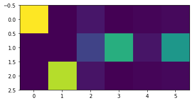

```python
fig, ax=plt.subplots(1)
ax.imshow(weights.T)
```

The weights (coloring) indicate the relative importance of each topic per album. For example, topic 1 is highly present in album 4 (Flower Boy) and album 6 (CALL ME IF YOU GET LOST).

We can visualize the same information as a line chart. Let's add labels to indicate the top words by each topic.

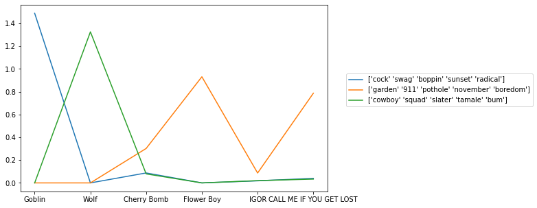

```python
fig, ax=plt.subplots(figsize = (8, 5))

for i in range(3):
    ax.plot(corpus_df['album'], weights[:,i], label = top_words(X, model, i, 5))

ax.legend(bbox_to_anchor=(1.05, 0.65), loc = 'upper left')
```

Interesting, relatively speaking, Tyler's first two albums are incredibly distinct in language and demonstrate his more 'radical' and youthful side. We see a little bit of a topic transformation during Cherry Bomb and a dramatic shift in language during the release of Flower Boy.

## Sentinment Analysis

Time for our most exciting part! Now that we have a good feel of Tyler's evolution on a very abstract level, let's attempt to classify the progression of positiveness of the artist soley based on his lyrics. As mentioned previously, Spotify actually keeps track of this feature in terms of `valence`, so in the end, we'll compare how our sentinment analyzer stacks up against Spotify's algorithm.

To peform this analysis, we are going to import the very handy `SentinmentIntensity Analyzer` using VADER. This classifier has been used widely on social media coprus, but let's see how it performs on Tyler's data! You can read more about its application [here](https://github.com/cjhutto/vaderSentiment).

```python
from vaderSentiment.vaderSentiment import SentimentIntensityAnalyzer
```

```python
analyzer = SentimentIntensityAnalyzer()
```

After creating an object of `SentimentIntensityAnalyzer`, we can create two seperate functions that will return 1) a sentiment score of the song lyrics and 2) classify the score as either Positive, Neutral, or Negative. The two functions that I created below will provide us with this ability.

```python
def sentiment_score_percent(l):
    try:
        sentiment_score = analyzer.polarity_scores(l)
        sentiment_percentage = sentiment_score['compound']

    except:
        sentinment_percentage = np.nan

    return sentiment_percentage
```

```python
def sentiment_score(l):
    try:
        sentiment_score = analyzer.polarity_scores(l)

        if sentiment_score['compound'] >= 0.05:
            sentiment = 'Positive'
        elif sentiment_score['compound'] > -0.05 and sentiment_score['compound'] < 0.05:
            sentiment = 'Neutral'
        elif sentiment_score['compound'] <= -0.05:
            sentiment = 'Negative'
    except:
        sentiment = np.nan

    return sentiment
```

Fantastic, now let's apply these functions to our original dataframe and score each song, creating two new columns in the process.

```python
df['sentiment_score'] = df['lyrics'].apply(sentiment_score)
```

```python
df['sentiment_percent'] = df['lyrics'].apply(sentiment_score_percent)
```

```python
df.head()
```

|  | song | album | lyrics | popularity | danceability | energy | key | loudness | mode | speechiness | ... | instrumentalness | liveness | valence | tempo | duration_ms | num_words | dirty_words | lex_rich | sentiment_score | sentiment_percent |
| --- | --- | --- | --- | --- | --- | --- | --- | --- | --- | --- | --- | --- | --- | --- | --- | --- | --- | --- | --- | --- | --- |
| 0 | Goblin | Goblin | You wouldn't do that Tyler, kill yourself or ... | 51 | 0.456 | 0.529 | 5 | -12.651 | 0 | 0.828 | ... | 0.000000 | 0.219 | 0.444 | 78.235 | 408520 | 1209 | 57 | 76.483379 | Negative | -0.9981 |
| 1 | Yonkers | Goblin | Uh, Wolf Haley, Golf Wang, go I'm a fuckin'... | 64 | 0.712 | 0.759 | 11 | -5.397 | 1 | 0.334 | ... | 0.080800 | 0.217 | 0.738 | 79.102 | 249333 | 550 | 50 | 95.478017 | Negative | -0.9971 |
| 2 | Radicals | Goblin | Random disclaimer! Hey, don't do anything tha... | 50 | 0.562 | 0.680 | 1 | -8.015 | 1 | 0.498 | ... | 0.095500 | 0.269 | 0.224 | 74.060 | 438333 | 834 | 160 | 21.398684 | Negative | -0.9997 |
| 3 | She | Goblin | Golden rubbers in these denim pockets On my ... | 73 | 0.350 | 0.621 | 8 | -6.495 | 0 | 0.233 | ... | 0.000034 | 0.613 | 0.459 | 83.375 | 253387 | 698 | 18 | 70.961011 | Positive | 0.9984 |
| 4 | Transylvania | Goblin | Left Brain, Wolf Haley Golf Wang, Free Earl, ... | 45 | 0.572 | 0.638 | 7 | -11.868 | 1 | 0.424 | ... | 0.010400 | 0.201 | 0.197 | 122.448 | 192200 | 590 | 62 | 57.262471 | Negative | -0.9996 |

5 rows × 21 columns

As always, time to plot!

```python
sentiment_score_df=df.groupby(['album', 'sentiment_score'])[['sentiment_score']].size().reset_index()
```

```python
sentiment_score_df
```

|  | album | sentiment_score | 0 |
| --- | --- | --- | --- |
| 0 | CALL ME IF YOU GET LOST | Negative | 7 |
| 1 | CALL ME IF YOU GET LOST | Positive | 9 |
| 2 | Cherry Bomb | Negative | 11 |
| 3 | Cherry Bomb | Positive | 2 |
| 4 | Flower Boy | Negative | 6 |
| 5 | Flower Boy | Neutral | 1 |
| 6 | Flower Boy | Positive | 7 |
| 7 | Goblin | Negative | 15 |
| 8 | Goblin | Positive | 1 |
| 9 | IGOR | Negative | 3 |
| 10 | IGOR | Positive | 9 |
| 11 | Wolf | Negative | 13 |
| 12 | Wolf | Positive | 5 |

```python
sentiment_score_df=sentiment_score_df.rename({0:'total'}, axis = 1)
```

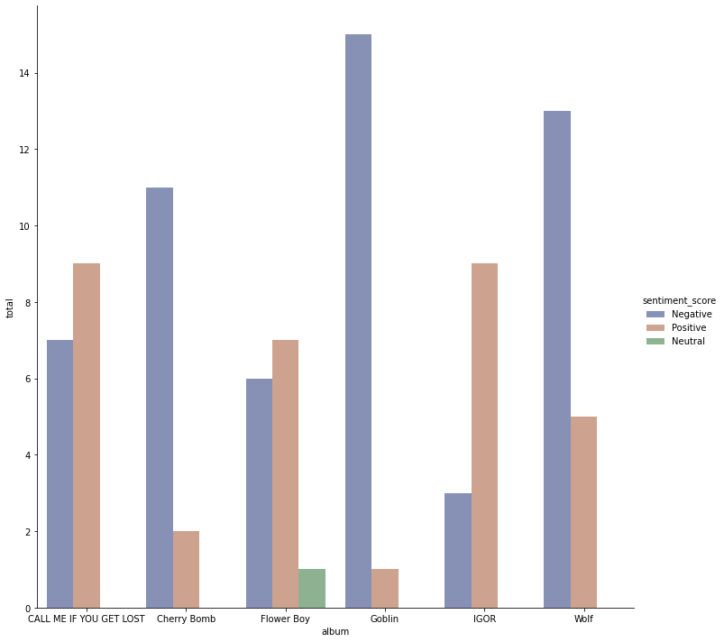

```python
import seaborn as sns

g = sns.catplot(
    data=sentiment_score_df, kind="bar",
    x="album", y="total", hue="sentiment_score",
    ci="sd", palette="dark", alpha=.5, height=10
)
```

*Note that albums are not displayed in ascending order by year*

We can clearly see that Tyler's first three albums (Goblin, Wolf, and Cherry Bomb) contain a lot more negative sentiment than his most recent albums (Flower Boy, Igor, and CALL ME IF YOU GET LOST).

Let's see this same information displayed by a line plot with a few other variables also plotted!

```python
df_sentiment = df.groupby(['album'])[['sentiment_percent']].mean().reset_index().reindex([3, 5, 1, 2, 4, 0])
```

```python
df_sentiment
```

|  | album | sentiment_percent |
| --- | --- | --- |
| 3 | Goblin | -0.858400 |
| 5 | Wolf | -0.445383 |
| 1 | Cherry Bomb | -0.620438 |
| 2 | Flower Boy | 0.106729 |
| 4 | IGOR | 0.420908 |
| 0 | CALL ME IF YOU GET LOST | 0.098738 |

```python
avg_album
```

|  | num_words | valence | popularity | acousticness | instrumentalness | energy | album |
| --- | --- | --- | --- | --- | --- | --- | --- |
| 0 | 1.695107 | -0.387798 | -1.519403 | -0.625024 | -0.629818 | -0.643182 | Goblin |
| 1 | 0.339973 | 0.967073 | -0.473521 | -0.700774 | -0.926070 | 0.256603 | Wolf |
| 2 | -0.021045 | -0.936811 | -0.860784 | -1.366263 | 1.556274 | 1.607985 | Cherry Bomb |
| 3 | -0.789977 | -0.414093 | 0.914235 | 1.631397 | 1.123016 | -1.199272 | Flower Boy |
| 4 | -1.516840 | -0.949773 | 1.039167 | 0.412805 | -0.097183 | -0.876040 | IGOR |
| 5 | 0.292782 | 1.721402 | 0.900307 | 0.647858 | -1.026219 | 0.853906 | CALL ME IF YOU GET LOST |

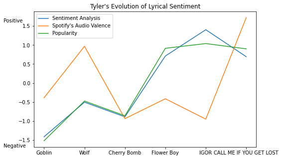

```python
fig, plt.subplots(figsize = (8, 5))
plt.plot(df_sentiment["album"], preprocessing.scale(df_sentiment['sentiment_percent']), label = 'Sentiment Analysis')
plt.title('Tyler\'s Evolution of Lyrical Sentiment')
plt.text(-1, 1.6, "Positive")
plt.text(-1, -1.7, "Negative")
plt.plot(df_sentiment['album'], avg_album['valence'], label = 'Spotify\'s Audio Valence')
plt.plot(df_sentiment['album'], avg_album['popularity'], label = 'Popularity')
plt.legend()
```

```python
np.corrcoef(avg_album['popularity'], preprocessing.scale(df_sentiment['sentiment_percent']))
```

```
array([[1.        , 0.98089692],
       [0.98089692, 1.        ]])
```

Again, we see this dramatic shift in lyrical positiveness after Cherry Bomb. Note how correlated Tyler's positivity is with his popularity (p=0.98). However, when plotted against Spotify's audio valence we notice a different story. This highlights the fact how many different dimensions Spotify's algorithm takes into account when classifying the mood of a song.

### General Discussion

```python
from IPython.display import display, HTML
display(HTML("<style>.container { width:100% !important; }</style>"))
from IPython.display import Image
```